# HW2

Joyce, Yameili, Tamires

9/20/2020

[output not shown]

```r
rolls_pp2<-sample(1:6,30,rep=T)
print(rolls_pp2)
```

```
##  [1] 2 1 6 2 5 5 5 6 5 4 6 1 2 3 5 6 4 3 3 1 2 3 4 3 6 3 2 2 1 6
```

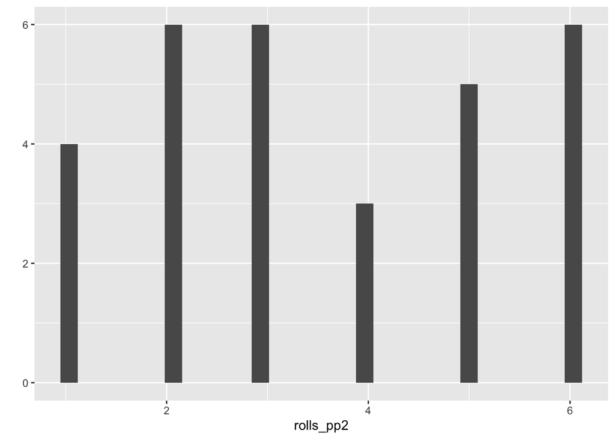

```r
library(ggplot2)
qplot(rolls_pp2,binwith=1)
```

```r
chisq.test(table(rolls_pp2), p = rep(1/6, 6))
```

```
##
##  Chi-squared test for given probabilities
##
## data:  table(rolls_pp2)
## X-squared = 1.6, df = 5, p-value = 0.9012
```

```
1) the probability of getting 6 five time
```

```r
x<-pbinom(5,30,1/6)
print(x)
```

```
## [1] 0.616447
```

2)the un-usualness of getting 1, 2,3 less than expected value

```r
x<-pbinom(4,30,1/6)
print(x)
```

```
## [1] 0.4243389
```

```r
x<-pbinom(3,30,1/6)
print(x)
```

```
## [1] 0.2396195
```

```r
x<-pbinom(2,30,1/6)
print(x)
```

```
## [1] 0.1027904
```

##the probability of getting less and less sixs become smaller, vice vesa.

##**PP3**: roll 100 times and specify decision rules. Some cases are easy: if every roll comes to 6 then might quickly conclude. But what about the edge cases? Is it fair to say that every conclusion has some level of confidence attached? Where do you set boundaries for decisions? Analyze PP3.

## Now roll it for 100 times

Repeat steps in PP2 **Step1** :Null Hypothesis: the observed value matches the excepted value: H0: p1=p2=p3=p4=p5=p6

Alternative Hypothesis Ha: the observed values don’t match the expected value.

**Step2**: we set up α=0.05 as the level of confidence and claim that the die is unfair.

```r
rolls_dice<-sample(1:6,100,rep=T)
print(rolls_dice)
```

```
##   [1] 2 3 4 1 6 6 4 2 6 6 5 5 1 5 5 1 2 5 5 6 3 2 2 1 6 1 3 1 1 2 4 4 1 2 1 4 1
##  [38] 1 4 3 5 5 1 5 4 4 1 1 3 1 4 5 2 5 4 2 2 2 3 4 4 2 5 6 2 4 4 6 1 6 3 3 3 4
##  [75] 4 1 2 4 3 3 2 6 1 2 1 5 3 3 5 1 2 2 6 6 3 6 4 1 4 1
```

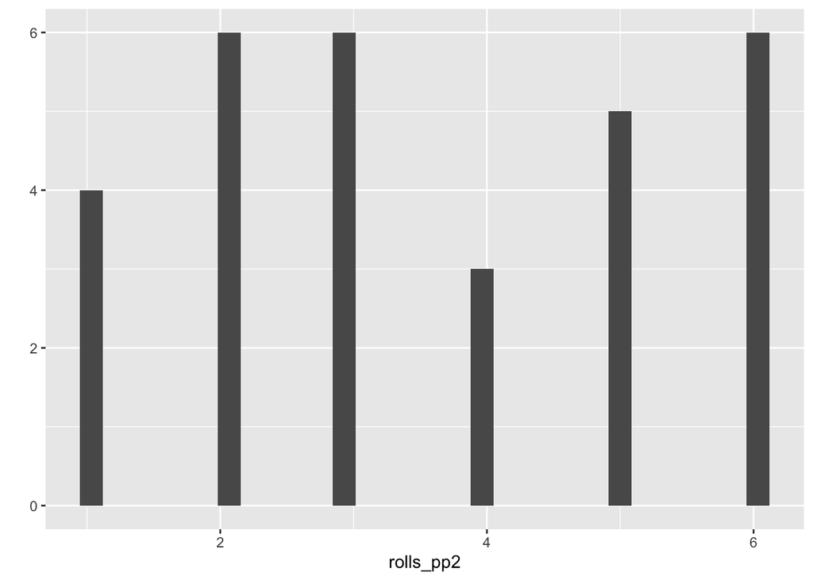

```r
library(ggplot2)
qplot(rolls_pp2,binwith=1)
```

**step3** simulation of 100 die rolls to set up randomly selected sample:

```r
chisq.test(table(rolls_dice),p=rep(1/6,6))
```

```
##
##  Chi-squared test for given probabilities
##
## data:  table(rolls_dice)
## X-squared = 3.8, df = 5, p-value = 0.5786
```

## roll it 1000 times

```r
roll_dice<-sample(1:6,1000,rep=T)
print(rolls_dice)
```

```
##   [1] 2 3 4 1 6 6 4 2 6 6 5 5 1 5 5 1 2 5 5 6 3 2 2 1 6 1 3 1 1 2 4 4 1 2 1 4 1
##  [38] 1 4 3 5 5 1 5 4 4 1 1 3 1 4 5 2 5 4 2 2 2 3 4 4 2 5 6 2 4 4 6 1 6 3 3 3 4
##  [75] 4 1 2 4 3 3 2 6 1 2 1 5 3 3 5 1 2 2 6 6 3 6 4 1 4 1
```

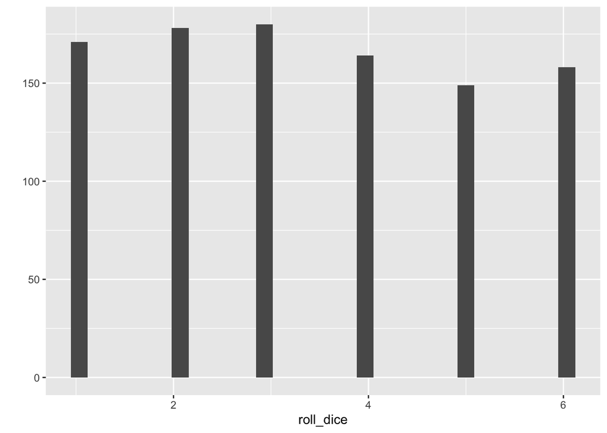

```r
library(ggplot2)
qplot(roll_dice,binwith=1)
```

### With the population becomes larger, the distribution of each side become equally smooth bit by bit.

##EP1## Testing for the mean value

scenario: If the die is fair, each of the number will have an equal probability. thus the mean of the population would be 3.5. *now we claim that the mean may be higher than 3.5.* to test our assumption, we simulate a 30 times die roll and set up a=0.05.

**step1**: Null hypothesis: H0: μ≤3.5 Ha: μ>3.5

**step2**: we use the data from pp2 which is 30 times rolls and run on a T-test to test the population mean.

**step3** calculation

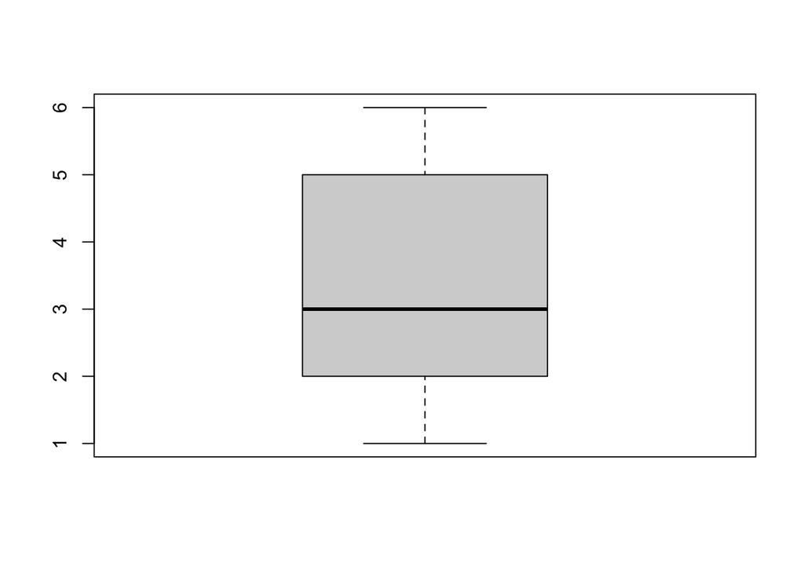

```r
boxplot(rolls_pp2)
```

```r
 #Ho: mu<=3.5
  #one-side 95% confidence interval for mu
  t.test(rolls_pp2,mu=3.5,alternative="greater",conf.level = 0.95)
```

```
##
##  One Sample t-test
##
## data:  rolls_pp2
## t = 0.20801, df = 29, p-value = 0.4183
## alternative hypothesis: true mean is greater than 3.5
## 95 percent confidence interval:
##  3.022096      Inf
## sample estimates:
## mean of x
##  3.566667
```

**Step1** Ho: p>=16% Ha: p<16%

**step2** check n=50, p=16% c=0.95 np=8.3>5 n(1-p)=41.7>5 alpha=1-c=0.05

**Step3** simulation and calculation

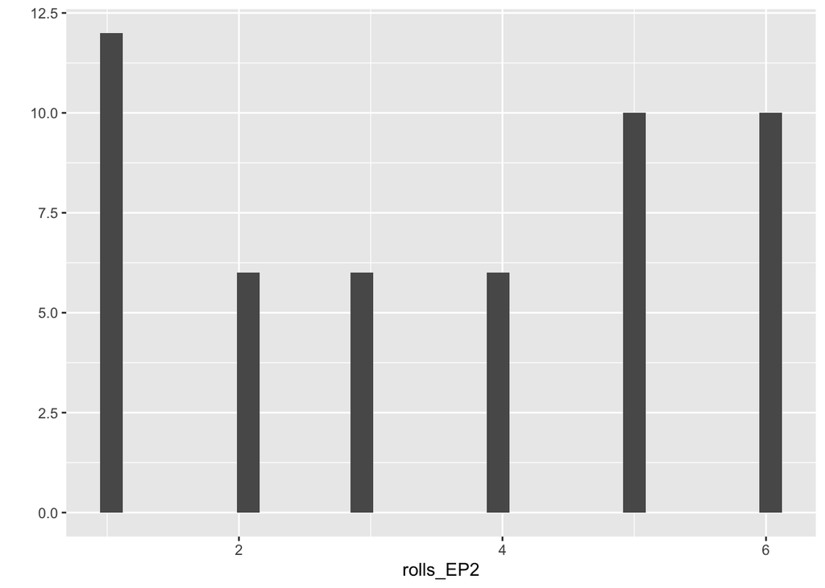

```r
rolls_EP2<-sample(1:6,50,rep=T)
library(ggplot2)
qplot(rolls_EP2,binwith=1)
```

```r
prop.test(6,50,p=0.16,alternative="less")
```

```
##
##  1-sample proportions test with continuity correction
##
## data:  6 out of 50, null probability 0.16
## X-squared = 0.33482, df = 1, p-value = 0.2814
## alternative hypothesis: true p is less than 0.16
## 95 percent confidence interval:
##  0.0000000 0.2275205
## sample estimates:
##    p
## 0.12
```

We have 0.2814>0.05. The P-value is greater than the alpha, thus we fail to reject the null hypothesis. At 95% confidence, we can’t provide enough evidence to support our assumption which is mean of the population will have less than 16% to be 3.5.